# From Exposure to Action

### A Data-Driven Career Compass for the AI Era

**Will AI replace human jobs, and which occupations are most at risk of AI-driven displacement, transformation, or augmentation — and what should students and working professionals do about it?**

This notebook is the Phase 1 analysis deliverable. See `docs/From_Exposure_to_Action_Data_Dictionary.xlsx` for the full research framework (typology, hypotheses, target variables, guardrails) and `README.md` for the project overview.

## 0. Setup

```python
import pandas as pd
import numpy as np
import matplotlib.pyplot as plt
import seaborn as sns
from scipy import stats
from IPython.display import display

pd.set_option("display.max_columns", 50)
sns.set_theme(style="whitegrid")
```

## 1. Data acquisition

Run once (or re-run to refresh) before this notebook can execute end to end:

```
python ../src/data_acquisition/fetch_aioe.py
python ../src/data_acquisition/fetch_onet.py
python ../src/data_acquisition/fetch_ilo_genai.py
python ../src/data_acquisition/fetch_bls_crosswalks.py
```

(Remaining fetchers -- OECD, BLS OEWS, GPTs are GPTs, Anthropic Economic Index, Statistics Canada -- are tracked in `src/data_acquisition/README.md`.)

## 2. Build the master occupation-level dataset

Joins AIOE + O*NET + ILO on occupation code via `src/crosswalks/` and `src/analysis/build_master_dataset.py`. Produces the Composite Exposure Score and a first-pass (provisional) Impact Pattern classification -- see that script's module docstring for the classification rule and its caveats.

```python
import sys
sys.path.insert(0, "../src")
from analysis.build_master_dataset import merge_all, save

# Run once (or re-run after adding a new source) to rebuild data/processed/master_occupations.csv.
# Requires fetch_aioe.py and fetch_onet.py to have been run first (see Section 1).
master = merge_all()
save(master)
master.head()
```

```
Loading AIOE (SOC-level exposure score) ...
```

```
  774 SOC occupations with an AIOE score
Loading O*NET occupation list (O*NET-SOC -> SOC) ...
```

```
  1016 O*NET-SOC occupations
Loading O*NET Job Zones ...
Loading O*NET skill profile (Essential Skills, Importance ratings) ...
```

```
Loading ILO occupation-level exposure scores (ISCO-08) ...
```

```
  427 ISCO-08 occupations with an ILO score
Loading ILO task-level scores and classifying impact_pattern ...
```

```
  impact_pattern counts: {'Transformation': 208, 'Augmentation': 160, 'Automation': 59}
Building ISCO-08 -> SOC 2018 crosswalk and mapping ILO onto it ...
```

```
  840 SOC 2018 occupations with ILO data after aggregation
Merging AIOE + O*NET + ILO on soc_code ...
```

|  | soc_code | occupation_title | aioe_score | ilo_score | composite_exposure_score | impact_pattern | job_zone | skill__active_learning | skill__active_listening | skill__critical_thinking | skill__learning_strategies | skill__mathematics | skill__monitoring | skill__reading_comprehension | skill__science | skill__speaking | skill__writing | ilo_task_mean | ilo_task_std |
| --- | --- | --- | --- | --- | --- | --- | --- | --- | --- | --- | --- | --- | --- | --- | --- | --- | --- | --- | --- |
| 0 | 11-1011 | Chief Executives | 1.334246 | 0.330000 | 0.807013 | Automation | 5.0 | 3.75 | 4.00 | 4.25 | 3.25 | 3.065 | 3.875 | 4.06 | 1.87 | 4.125 | 4.12 | 0.330000 | 0.080000 |
| 1 | 11-1021 | General and Operations Managers | 0.574877 | 0.401429 | 0.693407 | Transformation | 4.0 | 3.62 | 4.00 | 3.88 | 3.00 | 2.620 | 4.000 | 4.00 | 1.50 | 4.000 | 3.50 | 0.401429 | 0.094286 |
| 2 | 11-1031 | Legislators | NaN | 0.270000 | -0.167232 | Augmentation | 4.0 | NaN | NaN | NaN | NaN | NaN | NaN | NaN | NaN | NaN | NaN | 0.270000 | 0.070000 |
| 3 | 11-2011 | Advertising and Promotions Managers | 1.294387 | 0.390000 | 1.010589 | Automation | 4.0 | 3.38 | 4.12 | 3.88 | 3.00 | 2.880 | 3.500 | 3.75 | 1.50 | 4.120 | 3.75 | 0.390000 | 0.050000 |
| 4 | 11-2021 | Marketing Managers | 1.315032 | 0.410000 | 1.095414 | Transformation | 4.0 | 3.88 | 4.12 | 3.88 | 3.25 | 3.000 | 3.880 | 3.88 | 1.75 | 4.000 | 3.25 | 0.410000 | 0.090000 |

## 3. RQ1 — Consolidated risk ranking across indices

Top/bottom occupations by composite AI exposure. **Currently uses AIOE + ILO only** (the two indices joined so far in `build_master_dataset.py`) -- OECD and GPTs-are-GPTs are tracked as `[ ] later pass` in `src/data_acquisition/README.md` and will extend the correlation matrix once added. Tests H1 with the sources on hand; not the full picture yet.

```python
master = pd.read_csv("../data/processed/master_occupations.csv")

N = 15
CATEGORY_COLORS = {
    "Automation": "#2a78d6",       # blue
    "Transformation": "#eb6834",   # orange
    "Augmentation": "#1baf7a",     # aqua
}
MISSING_COLOR = "#9a9993"  # occupations with no impact_pattern yet

ranked = master.dropna(subset=["composite_exposure_score"]).sort_values(
    "composite_exposure_score", ascending=False
)
print(f"{len(ranked)} of {len(master)} occupations have a composite exposure score.")

display_cols = ["soc_code", "occupation_title", "composite_exposure_score",
                "aioe_score", "ilo_score", "impact_pattern"]
top_n = ranked.head(N)[display_cols]
bottom_n = ranked.tail(N)[display_cols]

print(f"\nTop {N} highest-exposure occupations:")
display(top_n)
print(f"\nBottom {N} lowest-exposure occupations:")
display(bottom_n)
```

```
934 of 955 occupations have a composite exposure score.

Top 15 highest-exposure occupations:
```

|  | soc_code | occupation_title | composite_exposure_score | aioe_score | ilo_score | impact_pattern |
| --- | --- | --- | --- | --- | --- | --- |
| 625 | 43-9199 | Office and Administrative Support Workers, All... | 2.514839 | NaN | 0.630 | Automation |
| 111 | 15-2099 | Mathematical Science Occupations, All Other | 2.067827 | NaN | 0.570 | Transformation |
| 96 | 15-1242 | Database Administrators | 2.067827 | NaN | 0.570 | Automation |
| 99 | 15-1251 | Computer Programmers | 2.067827 | NaN | 0.570 | Automation |
| 109 | 15-2051 | Data Scientists | 2.067827 | NaN | 0.570 | Transformation |
| 102 | 15-1254 | Web Developers | 2.030576 | NaN | 0.565 | Automation |
| 585 | 43-4041 | Credit Authorizers, Checkers, and Clerks | 2.014818 | 1.440296 | 0.640 | Automation |
| 581 | 43-3099 | Financial Clerks, All Other | 1.993325 | NaN | 0.560 | Automation |
| 71 | 13-2061 | Financial Examiners | 1.983200 | 1.526064 | 0.620 | Automation |
| 592 | 43-4131 | Loan Interviewers and Clerks | 1.976868 | 1.364395 | 0.640 | Automation |
| 575 | 43-3021 | Billing and Posting Clerks and Machine Operators | 1.961398 | 1.333455 | 0.640 | Automation |
| 98 | 15-1244 | Network and Computer Systems Administrators | 1.918823 | NaN | 0.550 | Automation |
| 292 | 25-4022 | Librarians and Media Collections Specialists | 1.918823 | NaN | 0.550 | Automation |
| 619 | 43-9041 | Insurance Claims and Policy Processing Clerks | 1.914771 | 1.240201 | 0.640 | Automation |
| 66 | 13-2041 | Credit Analysts | 1.892802 | 1.345268 | 0.620 | Automation |

```
Bottom 15 lowest-exposure occupations:
```

|  | soc_code | occupation_title | composite_exposure_score | aioe_score | ilo_score | impact_pattern |
| --- | --- | --- | --- | --- | --- | --- |
| 653 | 47-2061 | Construction Laborers | -1.565628 | -1.622988 | 0.09 | Augmentation |
| 671 | 47-2221 | Structural Iron and Steel Workers | -1.569664 | -1.780065 | 0.11 | Augmentation |
| 649 | 47-2043 | Floor Sanders and Finishers | -1.591244 | -1.748722 | 0.10 | Augmentation |
| 677 | 47-3015 | Helpers--Pipelayers, Plumbers, Pipefitters, an... | -1.593572 | -1.678876 | 0.09 | Augmentation |
| 652 | 47-2053 | Terrazzo Workers and Finishers | -1.604915 | -1.776065 | 0.10 | Augmentation |
| 651 | 47-2051 | Cement Masons and Concrete Finishers | -1.605586 | -1.777407 | 0.10 | Augmentation |
| 703 | 47-5061 | Roof Bolters, Mining | -1.618518 | -1.618518 | NaN | NaN |
| 644 | 47-2021 | Brickmasons and Blockmasons | -1.631304 | -1.754340 | 0.09 | Augmentation |
| 668 | 47-2171 | Reinforcing Iron and Rebar Workers | -1.665130 | -1.970997 | 0.11 | Augmentation |
| 438 | 31-1015 | Orderlies | -1.679232 | -1.679232 | NaN | NaN |
| 678 | 47-3016 | Helpers--Roofers | -1.703244 | -1.898220 | 0.09 | Augmentation |
| 682 | 47-4031 | Fence Erectors | -1.705190 | -1.902113 | 0.09 | Augmentation |
| 321 | 27-2031 | Dancers | -1.716503 | -2.669758 | 0.19 | Transformation |
| 673 | 47-3011 | Helpers--Brickmasons, Blockmasons, Stonemasons... | -1.725279 | -1.942290 | 0.09 | Augmentation |
| 676 | 47-3014 | Helpers--Painters, Paperhangers, Plasterers, a... | -1.776554 | -2.044840 | 0.09 | Augmentation |

```python
# Do the two available indices agree on which occupations are exposed?
# AIOE (Felten/Raj/Seamans, LLM-linguistic-task-based) and ILO (Gmyrek et al.,
# GPT-4o/Gemini task-rating-based) use different methodologies, so agreement here
# is informative even with just these two -- a low/insignificant rho would say the
# indices disagree more than expected, which matters as much as a high one.
paired = master.dropna(subset=["aioe_score", "ilo_score"])
rho, p_value = stats.spearmanr(paired["aioe_score"], paired["ilo_score"])
print(f"Spearman rho (AIOE vs ILO), n={len(paired)}: {rho:.3f} (p={p_value:.2e})")

print("\nimpact_pattern distribution (occupations with a value):")
print(master["impact_pattern"].value_counts())
print(f"({master['impact_pattern'].isna().sum()} occupations have no impact_pattern -- "
      "no ILO task-level match, see build_master_dataset.py)")
```

```
Spearman rho (AIOE vs ILO), n=680: 0.805 (p=4.86e-156)

impact_pattern distribution (occupations with a value):
impact_pattern
Transformation    401
Augmentation      339
Automation        100
Name: count, dtype: int64
(115 occupations have no impact_pattern -- no ILO task-level match, see build_master_dataset.py)
```

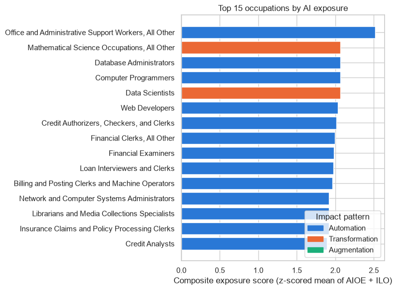

```python
fig, ax = plt.subplots(figsize=(8, 6))
plot_df = top_n.iloc[::-1]  # reverse so the highest-exposure occupation plots on top
colors = plot_df["impact_pattern"].map(CATEGORY_COLORS).fillna(MISSING_COLOR)
ax.barh(plot_df["occupation_title"], plot_df["composite_exposure_score"], color=colors)
ax.set_xlabel("Composite exposure score (z-scored mean of AIOE + ILO)")
ax.set_title(f"Top {N} occupations by AI exposure")
handles = [plt.Rectangle((0, 0), 1, 1, color=c) for c in CATEGORY_COLORS.values()]
ax.legend(handles, CATEGORY_COLORS.keys(), title="Impact pattern", loc="lower right")
plt.tight_layout()
plt.show()
```

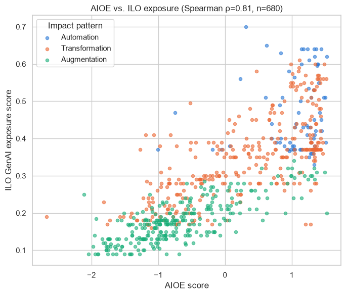

```python
fig, ax = plt.subplots(figsize=(7, 6))
for pattern, color in CATEGORY_COLORS.items():
    subset = paired[paired["impact_pattern"] == pattern]
    ax.scatter(subset["aioe_score"], subset["ilo_score"], s=20, alpha=0.6,
               color=color, label=pattern)
no_pattern = paired[paired["impact_pattern"].isna()]
if len(no_pattern):
    ax.scatter(no_pattern["aioe_score"], no_pattern["ilo_score"], s=20, alpha=0.4,
               color=MISSING_COLOR, label="(no impact_pattern)")
ax.set_xlabel("AIOE score")
ax.set_ylabel("ILO GenAI exposure score")
ax.set_title(f"AIOE vs. ILO exposure (Spearman ρ={rho:.2f}, n={len(paired)})")
ax.legend(title="Impact pattern")
plt.tight_layout()
plt.show()
```

**Reading this section:** the ranking above is associative, not predictive -- a high composite score describes an occupation's task content as measured by two LLM-exposure methodologies today, not a forecast of job loss (see the project's guardrails in `README.md`). The Spearman correlation is the key sanity check: if AIOE and ILO disagreed strongly (rho near 0 or negative) it would say the two methodologies are capturing different things and the composite score should be read cautiously until OECD and GPTs-are-GPTs are added to triangulate further. Revisit both the ranking and this correlation once those sources join the master table.

## 4. RQ2 -- Automation vs. Transformation vs. Augmentation

`impact_pattern` in the master table is now populated from ILO's task-level score variance (see `build_master_dataset.py`'s module docstring for the classification rule). This is a first-pass, provisional heuristic -- cross-check it here against the Anthropic Economic Index's own automation/augmentation usage split once that source is added (tests H2).

## 5. RQ3 — Task-level vulnerability

Which tasks within an occupation carry the highest ILO exposure scores.

## 6. RQ4 — Protective skill profile

Compare O*NET skill/ability distributions between high- and low-exposure occupation groups (tests H4).

## 7. RQ5 — Theoretical exposure vs. realized labor-market impact

Correlate composite exposure score against BLS OEWS multi-year employment/wage growth, and against Anthropic Economic Index actual-usage share (tests H3). Associative only — not a forecast.

## 8. Student layer — education path vs. exposure

Join O*NET Job Zones (education/experience/training required) to the composite exposure score; aggregate by education level.

## 9. Professional layer — reskilling paths

Occupation-to-occupation skill-vector similarity to surface, for a given high-exposure occupation, the nearest lower-exposure alternatives and the skill gap to close.

## 10. Appendix — Canada in context

One comparison chart: Statistics Canada's own NOC-based AI exposure estimates against the equivalent global/US-ranked occupations. Not a parallel pipeline (see README guardrails).

## 11. Summary & what this means for you

Decision-support framing only — evidence, risks, opportunities, skills, and alternatives; never a single prescriptive recommendation. Sets up the Phase 2 web app's dashboard fields (see the Data Dictionary's "Phase 2 Tool Design" tab).